# Practical Machine Learning Course Project

Yellow Duck

October 4, 2019

## Summary

Using devices such as Jawbone Up, Nike FuelBand, and Fitbit it is now possible to collect a large amount of data about personal activity relatively inexpensively. One thing that people regularly do is quantify how much of a particular activity they do, but they rarely quantify how well they do it. In this project, your goal will be to use data from accelerometers on the belt, forearm, arm, and dumbell of 6 participants. They were asked to perform barbell lifts correctly and incorrectly in 5 different ways.

In this project, the goal will be to use data from accelerometers on the belt, forearm, arm, and dumbell of 6 participants to predict the manner in which they did the exercise.

More information is available from the website http://groupware.les.inf.puc-rio.br/har.

# Environment Preparation and Data Loading

## Environment Preparation

The fist step is to load required libraries and set the seed, with Warnings and Messages hidden.

```r
library(caret)
library(corrplot)
library(dplyr)
library(plyr)
library(randomForest)

set.seed(12345)
```

Then to download and load datasets are available here:

- pml-training.csv
- pml-testing.csv

```r
url = "https://d396qusza40orc.cloudfront.net/predmachlearn/"

fileTrain = "pml-training.csv"
fileTest  = "pml-testing.csv"

if (!file.exists(paste0(getwd(), fileTrain))) {
  download.file(paste0(url, fileTrain), destfile=paste0(getwd(), "/", fileTrain), method = "curl");
}
if (!file.exists(paste0(getwd(), fileTest))) {
  download.file(paste0(url, fileTest), destfile=paste0(getwd(), "/", fileTest), method = "curl");
}

train = read.csv("pml-training.csv", header = TRUE, na.strings = c("NA", ""), stringsAsFactors = FALSE)
test  = read.csv("pml-testing.csv",  header = TRUE, na.strings = c("NA", ""), stringsAsFactors = FALSE)
```

## Data Preparation

Data contains 160 variables, with **classe** as an output populated with **5** levels, A, B, C, D and E. Training dataset contains **19622** records, and testing dataset **20** records.

101 variables are populated in less than 60% records. There are multiple methods to replace missing data; however, for the purpose of the first attempt missing data were not replaced and only well populated variables were used in further steps.

```r
keepRecord = c((colSums(!is.na(train[,-ncol(train)])) >= 0.6*nrow(train)))
train = train[, keepRecord]
```

In addition, 3 variables were removed from further steps as non relevant (X, user_name) or difficult to map and use in feature selection process (cvtd_timestamp).

```r
train = subset(train, select = -c(X, user_name, cvtd_timestamp))
```

Remaining non numeric variables were mapped into numeric representation and correlaction of variables were estimated.

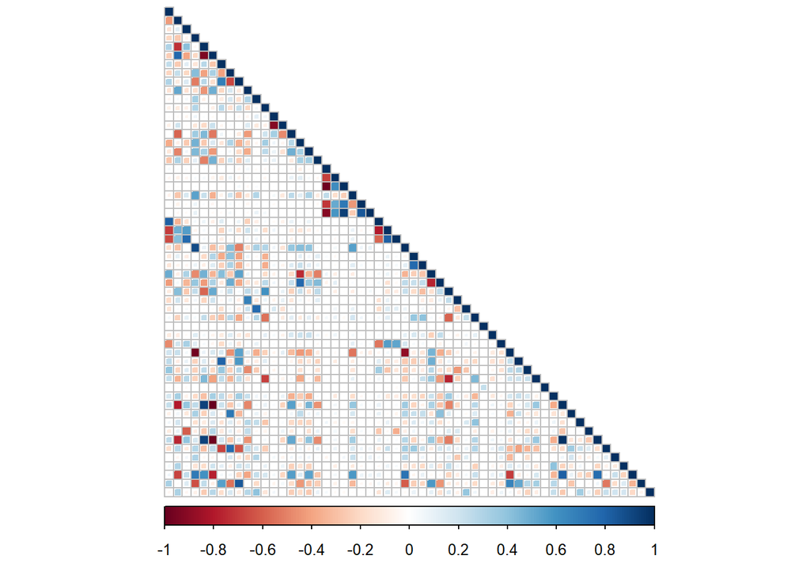

```r
# data preparation
train$new_window = as.character(train$new_window)
train$new_window = revalue(train$new_window, c("no" = 0, "yes" = 1))
train$new_window = as.numeric(train$new_window)

# correlaction calculation
descrCor <-  cor(select(train, -c(classe)))
corrplot(descrCor,  method = "square", order = "alphabet",  tl.col = "black", tl.srt = 45, type = "lower", bg = "white", tl.pos = 'n')
```

As visible on above chart there are highly correlated variables that will be removed from further analysis.

```r
highlyCor = findCorrelation(descrCor, cutoff = .7)
train = select(train, -highlyCor)
```

Data set contains now only 33 most important variables to estimate **classe** output variable.

# Model, validation and testing

## Data preparation

```r
train$classe = as.factor(train$classe)

inTrain = createDataPartition(train$classe, p = 0.7, list = FALSE)
validate = train[-inTrain,]
train = train[inTrain,]
```

## Model

```r
train.control = trainControl(method = "repeatedcv", number = 10, repeats = 3)
mod = randomForest(classe~., data = train, trControl = train.control)
print(mod)
```

```
##
## Call:
##  randomForest(formula = classe ~ ., data = train, trControl = train.control)
##                Type of random forest: classification
##                      Number of trees: 500
## No. of variables tried at each split: 5
##
##         OOB estimate of  error rate: 0.15%
## Confusion matrix:
##      A    B    C    D    E class.error
## A 3906    0    0    0    0 0.000000000
## B    2 2655    1    0    0 0.001128668
## C    0    5 2388    3    0 0.003338898
## D    0    0    8 2243    1 0.003996448
## E    0    0    0    0 2525 0.000000000
```

## Validation

```r
predV = predict(mod, validate)
confM = confusionMatrix(predV, validate$classe)
print(confM)
```

```
## Confusion Matrix and Statistics
##
##           Reference
## Prediction    A    B    C    D    E
##          A 1674    0    0    0    0
##          B    0 1139    1    0    0
##          C    0    0 1024    3    0
##          D    0    0    1  961    0
##          E    0    0    0    0 1082
##
## Overall Statistics
##
##                Accuracy : 0.9992
##                  95% CI : (0.998, 0.9997)
##     No Information Rate : 0.2845
##     P-Value [Acc > NIR] : < 2.2e-16
##
##                   Kappa : 0.9989
##
##  Mcnemar's Test P-Value : NA
##
## Statistics by Class:
##
##                      Class: A Class: B Class: C Class: D Class: E
## Sensitivity            1.0000   1.0000   0.9981   0.9969   1.0000
## Specificity            1.0000   0.9998   0.9994   0.9998   1.0000
## Pos Pred Value         1.0000   0.9991   0.9971   0.9990   1.0000
## Neg Pred Value         1.0000   1.0000   0.9996   0.9994   1.0000
## Prevalence             0.2845   0.1935   0.1743   0.1638   0.1839
## Detection Rate         0.2845   0.1935   0.1740   0.1633   0.1839
## Detection Prevalence   0.2845   0.1937   0.1745   0.1635   0.1839
## Balanced Accuracy      1.0000   0.9999   0.9987   0.9983   1.0000
```

```r
v = validate; v$classe  = revalue( v$classe, c("A" = 1, "B" = 2, "C" = 3, "D" = 4, "E" = 5));
RMSE_validate = sqrt(sum((as.numeric(predict(mod,newdata=v))-as.numeric(v$classe))^2))
```

Random Forest algorithms generates model with 99.92% accuracy for validation dataset. Out-of-sample error estimation: 2.24. That is good result, therefore model will be used to predict on testing dataset.

## Test

Test dataset needs to be transformed in similar manner as training.

```r
test = subset(test, select = -c(X, user_name, cvtd_timestamp))
test$new_window = as.character(test$new_window)
test$new_window = revalue(test$new_window, c("no" = "0", "yes" = "1"))
test$new_window = as.numeric(test$new_window)
```

Final step is to calculate prediction for test data set with 20 records.

```r
predT = predict(mod, test)
print(predT)
```

```
##  1  2  3  4  5  6  7  8  9 10 11 12 13 14 15 16 17 18 19 20
##  B  A  B  A  A  E  D  B  A  A  B  C  B  A  E  E  A  B  B  B
## Levels: A B C D E
```

Based on quiz assessment classification is **100%** correct.